# Predicting The Weather

4/24/2020

```r
library(readxl)
library(mosaic)
library(tidyverse)
library(pander)
library(DT)
```

## Graphical Summary

```r
BetterData <- read_excel("BetterData.xlsx")
```

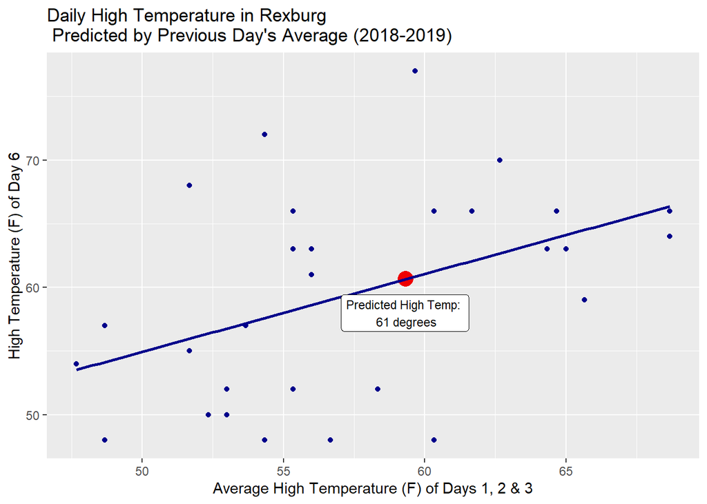

```r
ggplot(BetterData, aes(x = avg, y = highTemp))+
  geom_point(color = "darkblue", pch = 19)+
  geom_point(aes(x=59.3333, y=60.65), color="red2", pch=19, size = 5) +
  geom_smooth(method = "lm", se = FALSE, color = "darkblue")+
  labs(x= "Average High Temperature (F) of Days 1, 2 & 3", y = "High Temperature (F) of Day 6", title = "Daily High Temperature in Rexburg \n Predicted by Previous Day's Average (2018-2019)")+
  geom_label(x = 59.3, y = 58, label = "Predicted High Temp: \n 61 degrees", size = 3)
```

### **Predicted high temperature for Monday, April 27, 2020: 61 degrees Fahrenheit**

## Background

**It is important to note that the high temperature recorded and used in this analysis was not necessarily the daytime high, but simply the highest temperature recorded over the 24-hour period of one full day.**

I want to find if I can use the average of past days’ high temperatures to predict the high temperature 2 days in advance.

My chosen method for predicting the weather in Rexburg, Idaho was as follows: The day in question was set to be the sixth day of a sequence of days. In that same sequence of days, the high temperatures of days 1, 2, & 3 were averaged. This average was then assigned to be the independent variable, with the high temperature of day 6 as the response variable. I completed this process of a sequence of numbers for the first 24 days of April 2020 (since the prediction must be submitted by the 25th, that is as much data as is recorded), and the first 27 days of April in 2019 & 2018. The reason I elected to only use the first 27 days, is that we were asked to predict the weather for the 27th day of April 2020, and knowing that the changes in weather change based on the season and time of year, I chose to rely on the past times that would be expected to have changing weather patterns similar to the time we are predicting. Then, since I was allowed no more than 30 observations, I selected the year that had the least average difference between the 3 day average and the predicted day, which was 2018, but given that I only had 22 days worth of accurate data for 2018 (remember, that to be able to predict the sixth day, data on the 1st, 2nd and 3rd day must be known. However, since I ended my measurements on April 1st, I could only use the days April 27 through April 6, or 22 days), I also selected the sequence of April 27-April 21, 2019, to have a total of 29 data points. I selected 2019 because it had the second largest difference between explanatory and response variables.

For those interested, a full data table of the data used in this analysis can be found below:

```r
datatable(BetterData, options = list(lengthMenu=c(5,15,29)), extensions="Responsive")
```

|  | highTemp | avg |
| --- | --- | --- |
| 1 | 63 | 65 |
| 2 | 66 | 60.3333333333333 |
| 3 | 66 | 61.6666666666667 |
| 4 | 66 | 64.6666666666667 |
| 5 | 66 | 68.6666666666667 |
| 6 | 63 | 64.3333333333333 |
| 7 | 52 | 58.3333333333333 |
| 8 | 77 | 59.6666666666667 |
| 9 | 70 | 62.6666666666667 |
| 10 | 64 | 68.6666666666667 |

[output cut: 19 more lines]

The true regression equation is shown by this mathematical model:

$$\underbrace{Y_i}_\text{High Temperature}=\beta_0+\beta_1\underbrace{X_i}_\text{3-day Average}+\epsilon_i\text{ where }\epsilon_i\sim N(0,\sigma^2)$$

## Hypotheses

The hypotheses for this analysis will be with regards to $\beta_1$, which is the true regression slope. If $\beta_1=0$, then the high temperature for a given 6th day is not correlated with the average of the first 3 days of that sequence, as previsouly explained.

$$H_O: \beta_1=0$$
$$H_a: \beta_1 \neq0$$

The significance level for this test will be set at:

$$\alpha=0.05$$

## Analysis

```r
rex.lm <- lm(highTemp ~ avg, data = BetterData)
summary(rex.lm) %>%
  pander()
```

|  | Estimate | Std. Error | t value | Pr(>\|t\|) |
| --- | --- | --- | --- | --- |
| **(Intercept)** | 24.4 | 13.77 | 1.772 | 0.08767 |
| **avg** | 0.611 | 0.2387 | 2.559 | 0.01641 |

Fitting linear model: highTemp ~ avg

| Observations | Residual Std. Error | $R^2$ | Adjusted $R^2$ |
| --- | --- | --- | --- |
| 29 | 7.464 | 0.1952 | 0.1654 |

I reached my final prediction by looking at the high temperatures of April 22, 23 & 24, taking their average $(64+57+57)/3=59.333$ and then using the predict() function to estimate the high temperature on April 27, which was found to be:

```r
predict(rex.lm, data.frame(avg= 59.333)) %>% pander()
```

| 1 |
| --- |
| 60.65 |

A prediction interval has also been included for the desired day:

```r
predict(rex.lm, data.frame(avg = 59.333), interval = "prediction") %>% pander()
```

| fit | lwr | upr |
| --- | --- | --- |
| 60.65 | 45.04 | 76.26 |

## Conclusion

The above test summary can be written as the following linear relationship between the two considered variables:

$$\underbrace{\hat{Y_i}}_\text{Mean High Temp}=\underbrace{ 24.4}_{b_0}+\underbrace{0.611}_{b_1}\underbrace{X_i}_\text{3-day Average}$$

Given the p-value for our slope term $p=0.01641<\alpha=0.05$, we reject the null and have sufficient evidence to conclude that $\beta_1\neq0$. The slope can be interpreted to mean that for every 1 degree Fahrenheit increase in the 3-day average, the predicted day’s temperature increases by 0.61 degrees Fahrenheit, which also makes logical sense.

The intercept term, or $\beta_0$ is of little interest. Though a possibility of a 3-day average of 0 degrees F is possible, our estimate is not considered to be accurate due to the fact that all of the used data was in April, where a 3 day average of 0 degrees Fahrenheit is very unlikely, even in Rexburg. The smallest x-value was 47.667, which is a considerable distance from 0. The estimate for the intercept term given was also rather large $b_0=24.4$ which logically would not make sense, given that the 3 day average was 0, and an increase from 0 to 24.4 is a sizable change, though it would likely be a welcomed change by the residents of Rexburg, Idaho.

### Diagnostic Plots

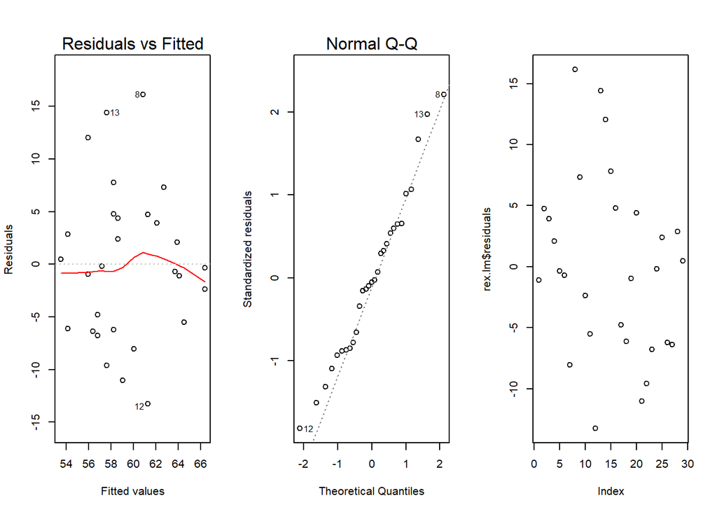

```r
par(mfrow=c(1,3))
plot(rex.lm,which=1:2)
plot(rex.lm$residuals)
```

These diagnostic plots show us that the p-value and graphical summary were too good to be true. There is clearly an issue with the constant variance, though linearity seems to be okay. The QQ-Plot shows us that the residuals are approximately normal, but the order plot also shows a bit of a figure-eight pattern, so we cannot conclude that the error terms are independent. Given these errors, we cannot conclude that the assumptions for a linear regression analysis have been met. We therefore are unable to trust the results of our regression.